# Transformando variables. Actividad 2

Carlos Cañizares

20 de Agosto 19

En algunas partes de nuestro que hacer actuarial no spodremos preguntar: ¿Cómo nuevas distribuciones pueden ser creadas a partir de otras ya existentes?. Esta pregunta es muy imporante dado que este tipo de “condiciones” o de transformaciones suelen aparecer en diversas aplicaciones Actuariales.

Exponemos las transformaciones más usuales:

### Multiplicación por una constante:

Este tipo de tranformación es usual al trabajar sobre transformaciones de varaibles que denoten pérdida. Dos de los ejemplos más clásicos de este tipo de transformación son la inflación y el coaseguro:

Consideremos una tasa de **inflación uniforme** $r\geq 0$ y tomemos $X$ el monto de pérdida asociado a un siniestro, vamos a pensar que, de materializarse un siniestro éste sufrirá un cambio en su valor monetario provocado por la inflación, de tal manera que la aseguradora deberá pagar:

$$Y=(1+r)X$$

Ahora, Denotando a $X$ como el monto de pérdida asociado a un siniestro, luego, tomemos $\alpha \epsilon (0,1]$ un **factor de coaseguro**, el cual es la proporción de pago que le corresponde a la CIA de seguros, mientras el poseedor de la póliza paga la fracción restante, la v.a. de pago por parte de la aseguradora es:

$$Y=\alpha X$$

Y vimos el teorema siguiente:

#### Teorema

Sea $X$ una v.a.c. con pdf y cdf conocida. Sea $Y=\theta X$ con $\theta >0$ entonces:

$$F_Y(y)=F_X(\frac{y}{\theta}) \hspace{2em};\hspace{2em} f_Y(y)=\frac{1}{\theta}f_X(\frac{y}{\theta})$$

*Nota: el soporte de Y estará dado por $\{y|\frac{y}{\theta}\in sop\{x\}\}$//*

Obtener la esperanza de esta variable aleatoria es trivial en términos de la esperanza de $X$, debido a la linealidad de la esperanza, se tiene que:

$$\mathbb{E}[Y]=\mathbb{E}[\theta X]=\theta\mathbb{E}[X]$$

Es claro, además, que el parámetro $\theta$ será un parámetro de escala para la variable Y

Ejemplo (coaseguro):

Sea $X\sim Unif(100,200)$ y consideremos $\theta=50\%$ así; $Y=\theta X$ implica que:

$f_Y(y)=\frac{1}{0.5}f_X\left(\frac{y}{0.5}\right)=2f_X(2y)=2\left(\frac{1}{200-100}\mathbb{I}_{(100,200)}^{(2y)}\right)$

*//*$100\leq2y\leq200 \Leftrightarrow 50\leq y \leq 100$*//*

$=\frac{1}{50}\mathbb{I}_{(50,100)}^{(y)}=\frac{1}{100-50}\mathbb{I}_{(50,100)}^{(y)}$

$\therefore Y=0.5X\sim Unif(50,100)$

$\Rightarrow \mathbb{E}[Y]=0.5\mathbb{E}[X]=0.5\left(\frac{100+200}{2}\right)=75$

Ejemplo (Inflación):

$f_Y(y)=\frac{1}{(1+r)}f_X\left(\frac{y}{(1+r)}\right)=\frac{1}{(1.1)}f_X\left(\frac{y}{(1.1)}\right)=\frac{1}{(1.1)(1000)}\mathbb{I}_{(0,1000)}^{\left(\frac{y}{1.1}\right)}$

*//* $0\leq \frac{y}{(1.1)}\leq1000 \Leftrightarrow 0\leq y \leq 1100$ *//*

$=\frac{1}{1100}\mathbb{I}_{(0,1100)}^{(y)}$

$\therefore Y=(1.1)X\sim Unif(0,1100)$

$\Rightarrow \mathbb{E}[Y]=(1+r)\mathbb{E}[X]=1.1\left(\frac{1000}{2}\right)=550$

*//Observación: La inflación aumenta el valor esperado del siniestro.//*

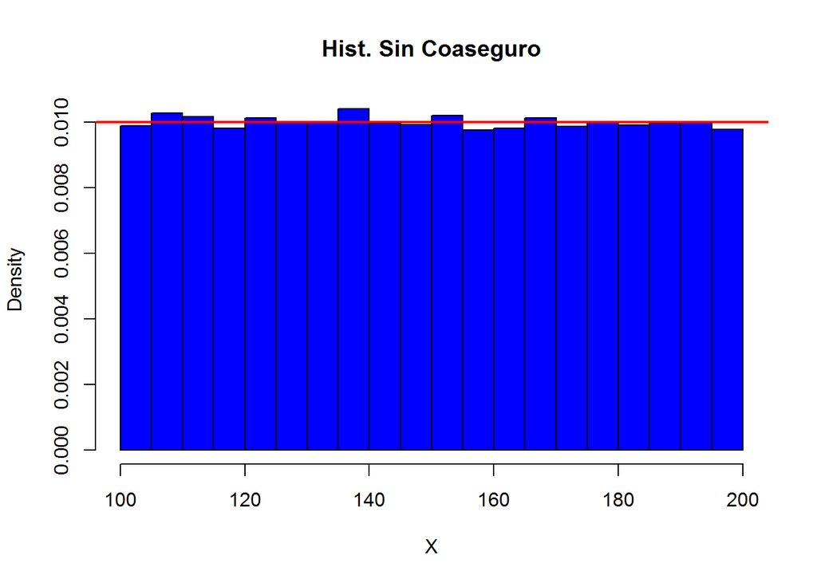

```r
###############
## Coaseguro ##
###############


## Uniforme
min<-100 ; max <- 200
set.seed(27)
X<-runif(100000,min,max)

## Fijamos un factor de coaseguro
alpha<-0.5
Y<-0.5*X

## Comparemos nuestras poblaciones

## Sin coaseguro
hist(X,col="blue",probability = T, main="Hist. Sin Coaseguro")
abline(h=1/100,col="red",lwd=2)
```

```r
mean(X)
```

```
## [1] 149.8164
```

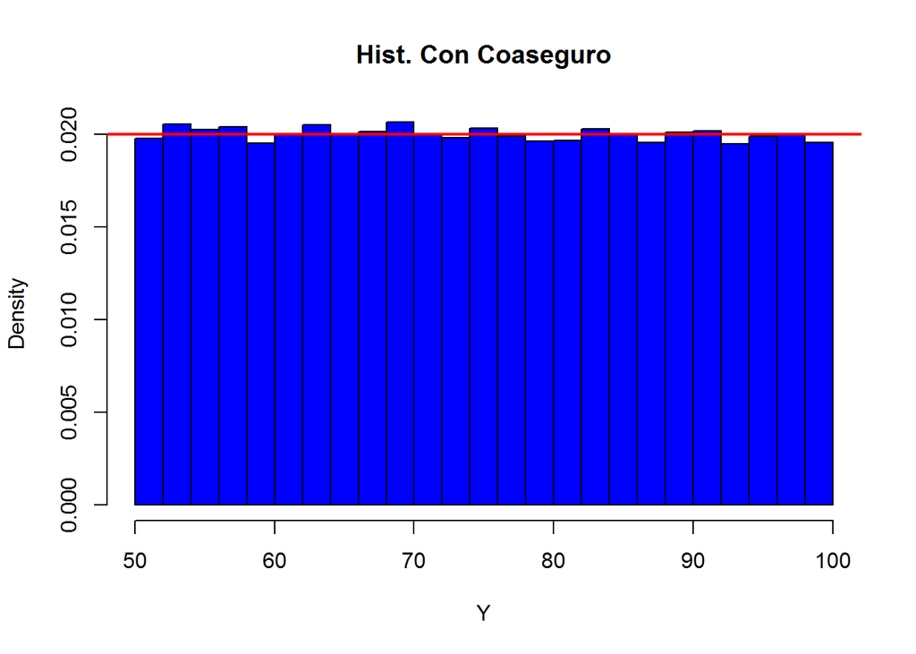

```r
## Con coaseguro
hist(Y,col="blue",probability = T,main="Hist. Con Coaseguro")
abline(h=1/50,col="red",lwd=2)
```

```r
0.5*mean(X)
```

```
## [1] 74.90819
```

```r
mean(Y)
```

```
## [1] 74.90819
```

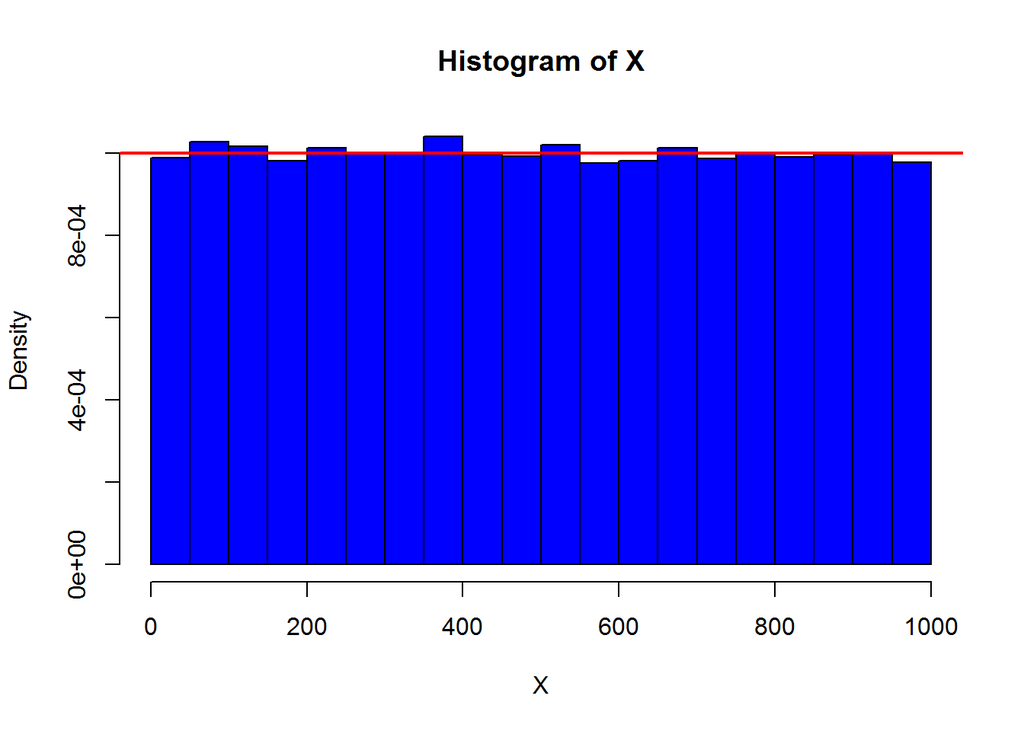

```r
###############
## Inflación ##
###############

## Uniforme
min<-0 ; max <- 1000
set.seed(27)
X<-runif(100000,min,max)

## Fijamos un factor de coaseguro
r<-0.1
Y<-(1+r)*X

## Comparemos nuestras poblaciones

## Sin inflación
hist(X,col="blue",probability = T)
abline(h=1/1000,col="red",lwd=2)
```

```r
mean(X)
```

```
## [1] 498.1638
```

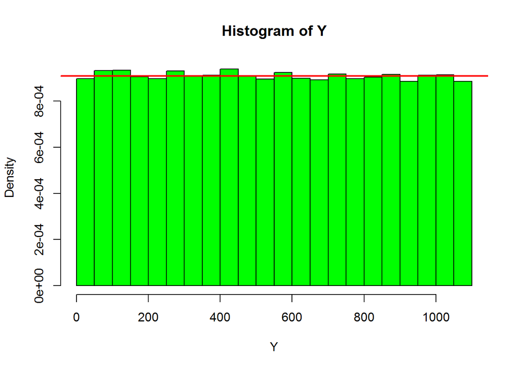

```r
## Con inflación
hist(Y,col="green",probability = T)
abline(h=1/1100,col="red",lwd=2)
```

```r
(1+r)*mean(X)
```

```
## [1] 547.9801
```

```r
mean(Y)
```

```
## [1] 547.9801
```

### Elevando a una potencia:

Este tipo de tranformación es muy usual y de aquí se desprenden diversas familias de distribuciones parámetricas que llevan el palleido de *inversa, transformada o transformada inversa*

#### Teorema

Sea $X$ una v.a.c. con pdf y cdf conocida y además $F_X(x)=0$. Sea $\displaystyle Y=X^{\frac{1}{\tau}}$ entonces:

1. Si $\tau>0$

$$F_Y(y)=F_X(y^{\tau}) \hspace{2em};\hspace{2em} f_Y(y)=\tau y^{\tau-1}f_X(y^\tau)$$

$$F_Y(y)=1-F_X(y^{\tau}) \hspace{2em};\hspace{2em} f_Y(y)=-\tau y^{\tau-1}f_X(y^\tau)$$

Aquí la observación es:

Además mostramos que si X tiene distribución exponencial y definimos a $Y=\theta X^{\frac{1}{\tau}}$. Operando primero sobre la tranformación de potencia y después evaluando sobre la operación de escala. Es decir haciendo primero $W=X^{\frac{1}{\tau}}$ y después $Y=\theta W$ mostramos que:

#### Inversa ($\tau=-1$)

$F(w)=e^{-\frac{1}{w}}$

$F(y)=e^{-\frac{\theta}{y}}$

y así:

$f(w)=w^{-2}e^-w^{-1}$

$f(y)=\frac{1}{\theta}*(\frac{y}{\theta})^{-2}*e^{-(\frac{y}{\theta})^{-1}}=\frac{\theta e^{-(\frac{\theta}{y})}}{y^2}$

Que es la distribución exponencial Inversa.

#### Exponencial Transformada ($\tau>0$)

$F(w)=1-e^{-w^{\tau}}$

$F(y)=1-e^{-(\frac{y}{\theta})^{\tau}}$

y así:

$f(w)=\tau w^{\tau - 1} e^{-w^{\tau}}$

$f(y)=\frac{1}{\theta}*\tau*(\frac{y}{\theta})^{\tau - 1}*e^{-(\frac{y}{\theta})^{\tau}}=\frac{\tau(\frac{y}{\theta})^{\tau} e^{-(\frac{y}{\theta})^{\tau}}}{y}$

Que es la distribución Weibull.

#### Inversa Transformada de la exponencial ($\tau<0$)

$F(w)=e^{-w^{-\tau}}$

$F(y)=e^{-(\frac{y}{\theta})^{-\tau}}=e^{-(\frac{\theta}{y})^{\tau}}$

y así:

$f(w)=-\tau w^{\tau - 1} e^{-w^{\tau}}$

$f(y)=\frac{1}{\theta}*-\tau*(\frac{y}{\theta})^{\tau - 1}*e^{-(\frac{y}{\theta})^{\tau}}=\frac{\tau(\frac{\theta}{y})^{\tau} e^{-(\frac{\theta}{y})^{\tau}}}{y}$

Que es la distribución Weibull Inversa.

```r
library(actuar)
```

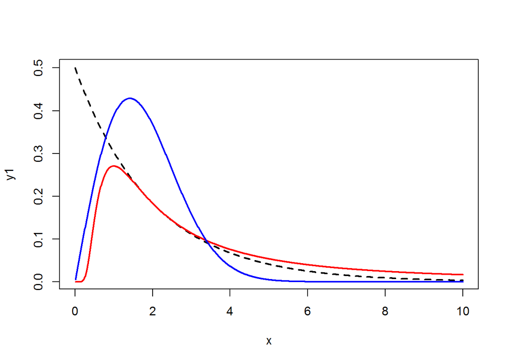

```r
## Transformación elevando a la potencia

## Exponencial normal
f1<-function(x,lambda){
  f<-(1/lambda)*exp(-x/lambda)
  return(f)
}


## Exponencial Inversa
f2<-function(y,lambda){
  f<-(lambda*exp(-lambda/y))/(y^2)
  return(f)
}


## Exponencial Transformada (Weibull)
f3<-function(y,lambda,tau){
  f<-(tau*((y/lambda)^tau)*exp(-(y/lambda)^tau))/y
  return(f)
}


x<-seq(0,10,by=0.01)
lambda<-2
tau<-2


y1<-f1(x,lambda)
y2<-f2(x,lambda)
y3<-f3(x,lambda,tau)

plot(x,y1,type="l",lty=2,lwd=2)
lines(x,y2,type = "l",col="red",lwd=2)
lines(x,y3,type = "l",col="blue",lwd=2)
```

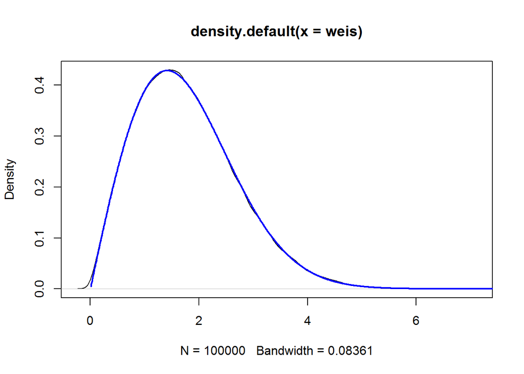

```r
### Quisiera comparar con la weibull

weis<-rweibull(100000,2,2)
plot(density(weis))
lines(x,y3,type = "l",col="blue",lwd=2)
```

### Exponenciación:

#### Teorema

Sea $X$ una v.a.c. con pdf y cdf conocida y además $f_X(x)>0$ para todo $x\in \mathbb{R}$. Sea $\displaystyle Y=exp(X)$ entonces para $y>0$:

$$F_Y(y)=F_X(ln(y)) \hspace{2em};\hspace{2em} f_Y(y)=\frac{1}{y}f_X(ln(y))$$

El ejemplo más claro de este es:

Considere $X\sim N(\mu,\sigma^2)$. Determinar cdf y pdf de $Y=e^{X}$

$F_Y(y)=F_x(ln(y))=\Phi(\frac{ln(y) - \mu}{\sigma})$

$f_Y(y)=\frac{1}{y}f_x(ln(y))=\frac{1}{y}*\frac{1}{\sqrt{2\pi \sigma^2}}* e^{-\frac{(ln(y)-\mu)^2}{2\sigma^2}}$

Que es una distribución Lognormal, además si agregamos una nueva variable aleatoria llamada $Z=\theta Y$ demostramos que esta tiene distribución Lognormal, pero la adición de un tercer parámetro no adiciona valor. ¿Porqué?

### Mezcla

#### Teorema

Sea $X$ una v.a con pdf $f_{x|\Lambda}(x|\lambda)$ y cdf $F_{x|\Lambda}(x|\lambda)$ conocida donde $\lambda$ es un parámetro de $X$. Si bien “X” puede tener otros parámetros, ests no serán relevantes. Consideremos $\lambda$ una realización de la v.a. $\Lambda$ con pdf $f_\Lambda(\lambda)$, entonces la probabilidad incondicional de $X$ es:

$$f_X(x)=\int f_{x|\Lambda}(x|\lambda) f_\Lambda(\lambda) d\lambda$$

Además mostramos en clase que:

$$F_X(x)=\int F_{x|\Lambda}(x|\lambda) f_\Lambda(\lambda) d\lambda$$

Que nos permitió ver a ambas como una esperanza, específicamente:

$$f_X(x)=\mathbb{E}_{\Lambda}[f_{x|\Lambda}(x|\lambda)]$$
$$F_X(x)=\mathbb{E}_{\Lambda}[F_{x|\Lambda}(x|\lambda)]$$

Que tiene sentido visto desde el punto de vista empírico o de razón.

Además demostramos que:

$$\mathbb{E^k}=\mathbb{E}[\mathbb{E(X^k|\Lambda)}]$$
Lo cual de nuevo nos hace sentido, el k-ésimo momento debería ir acorde a obtener la esperanza de todas las esperanzas condicionadas de las observaciones de la variable aleatoria $\Lambda$.

Además vimos que:

$$\mathbb{Var}(x)=\mathbb{E}[\mathbb{Var}(X|\Lambda)]+\mathbb{Var}(\mathbb{E}[X|\Lambda])$$
Que de nuevo pareciera ser un resultado razonable desde el punto de vista no abstracto.

Además, observamos dinstintas cosas:

1. Si $f_\Lambda(\lambda)$ es discreta, las integrales calculadas pueden ser facilmente reemplazadas por sumas.
2. Las distribuciones de Mezclas tienden a ser de colas muy pesadas, por ello, este método es una buena forma de genera un modelo con estas características dado que si $f_{X|\Lambda}(x|\lambda)$ tiene una tasa de riesgo decreciente (cola pesada) entonces la mezcla también tendra una tasa de riesgo decreciente (en ocasiones más decreciente).

#### De este ejemplo se pidió:

Considerando $X|\Lambda$ una distribución $exp(\frac{1}{\Lambda})$. Considerando que $\Lambda \sim Gamma(\alpha,theta)$, determinar la distribución incondicional de $X$.

Si $\Lambda \sim Gamma(\alpha,theta)$ entonces:

$$f(\lambda)=\frac{(\theta\lambda)^{\alpha-1}}{\Gamma(\alpha)} \theta e^{-\theta \lambda}$$

Además si $X|\Lambda$ tiene distribución $exp(\frac{1}{\Lambda})$

$$f(x)=\lambda e^{-x\lambda}$$

Por lo que:

$$f_X(x)=\int_{0}^{\infty}\lambda e^{-x\lambda} * \frac{e^{-\theta \lambda} \theta (\theta \lambda )^{\alpha-1}}{\Gamma(\alpha)}$$

así:

$$f_X(x)=\frac{\theta^{\alpha}}{\Gamma(\alpha)} \int_{0}^{\infty} \lambda e^{-\lambda x} \lambda^{\alpha-1} e^{-\theta \lambda}$$

Por lo que:

$$f_X(x)=\frac{\theta^{\alpha}}{\Gamma(\alpha)} \int_{0}^{\infty} \lambda^{\alpha} e^{-\lambda (x+\theta)}$$

Y finalmente:

La cual es la densidad de una Pareto!!!!!

# Entonces de tarea tendrán lo siguiente:

# 1. De los ejercicios descritos para exponenciación y de mezclas, realice el código de R que muestre que efectivamente las distribuciones encontradas (o “creadas”) son efectivamente las que estamos buscando.

Queriamos ver que la exponenciación de una Normal se convierte en una Lognormal:

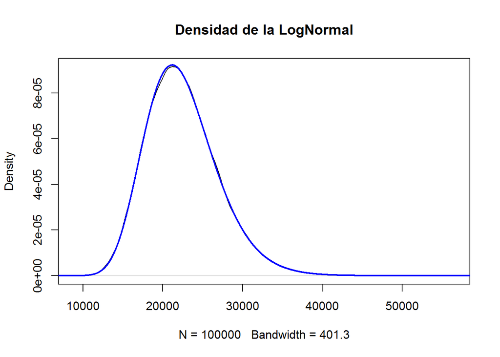

```r
## funcion de densidad de la transformacion

expo<- function(y,mu,sigma){
  exp<-(1/y)*(1/(2*pi*sigma^2)^(1/2))*exp(-((log(y)-mu)^2)/(2*sigma^2))
  return(exp)
}


n<-100000
mu<-10
s<-0.2

x<-seq(0,n,by= 10)
y<-expo(x,mu,s)


plot(density(rlnorm(n,mu,s)),main = "Densidad de la LogNormal")
lines(x,y,type = "l" ,col= "blue",lwd=2,lty=1)
```

Luego veriamos que la mezcla de la exponencial donde su parámetro es gamma es una pareto

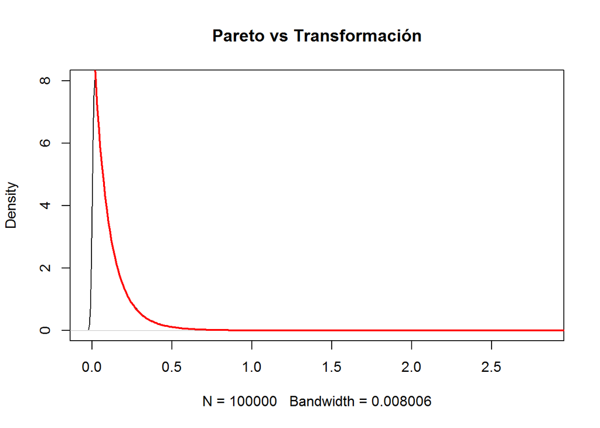

```r
## funcion de densidad de la transformacion

library("actuar")

trans<- function(y,alpha,theta){
  x<-(alpha*theta^alpha)/((y+theta)^(alpha + 1))
  return(x)
}

x<-seq(0,7,by=0.01)
y<-trans(x,11,1.1)


plot(density(rpareto(100000,11,1.1)),main = "Pareto vs Transformación")
lines(x,y,type = "l" ,col= "red",lwd=2)
```

2. Considere $X$ con distribución $Pareto(\alpha,\beta)$. Considere a $Y=ln(1+\frac{X}{\theta})$. Determine el nombre de la distribución $Y$ y sus parámetros. Después genere un código en R que compare a ambas y muestre que efectivamente son la misma distribución.

$$F_Y(y)=\mathbb{P}(Y\leq y)=\mathbb{P}(ln(1+X/\theta)\leq y)$$
luego

$$=\mathbb{P}(1+X/\theta\leq e^y)=\mathbb{P}(X\leq \theta(e^y-1))$$
evaluando esta distribución:
$$=1-[\frac{\theta}{\theta+\theta(e^y-1)}]^\alpha=1-(\frac{1}{e^y})^\alpha=1-e^{-\alpha y}$$
La cual es una distribución exponencial con parámetro $1/\alpha$

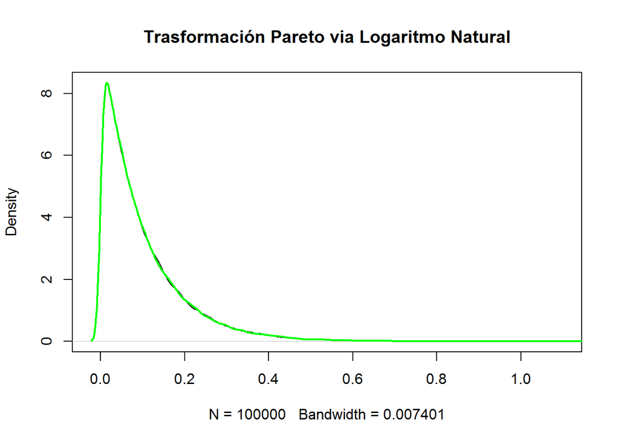

```r
n <- 100000

alpha <- 10
beta <- 4
theta <- 4

x<-rpareto(n, alpha, theta)
y<-log(1+ x/theta)

exponen<-rexp(100000, alpha)

plot(density(exponen), main = "Trasformación Pareto via Logaritmo Natural")
lines(density(y), type = "l", col="green", lwd=2)
```

3. Considere $X$ con distribución $Pareto(\alpha,\beta)$. determine la cdf de la distribución inversa, transformada e inversa transformada. ¿Estas “nuevas” distribuciones tiene un nombre en especial?. Después genere un código en R que compare a ambas y muestre que efectivamente son la misma distribución.

Inversa:

$$F_Y(y)=1-[1-(\frac{\theta}{\theta+y^{-1}})^\alpha]=(\frac{y}{y+\theta^{-1}})^\alpha$$
Que es la Pareto inversa con $\tau=\alpha$ y $\theta=1/\theta$

Transformada:

$$F_Y(y)=1-(\frac{\theta}{\theta+y^\tau})^\alpha$$

Que es la distribución Burr con $\alpha=\alpha$, $\gamma=\tau$ y $\theta=\theta^{\frac{1}{\tau}}$

Transformada Inversa:

$$F_Y(y)=1-[1-(\frac{\theta}{\theta+y^{-\tau}})^\alpha]=(\frac{y^\tau}{y^\tau+(\theta^{-1/\tau})^\tau})^\alpha$$

Que es la distribución Burr inversa con $\tau=\alpha$, $\gamma=\tau$ y $\theta=\theta^{-\frac{1}{\tau}}$

### Burr

[figure not shown]

```r
set.seed(553878)
tau <- 8
alpha<-2
beta<-3
paretos<-rpareto(100000, alpha, beta)
y <- paretos^(1/tau)


burrs<-rburr(100000, alpha, tau, theta^(-1/tau))

plot(density(burrs), main = "Pareto Trans = Burr")
lines(density(y), type = "l", col="darkgreen", lwd=2)
```

### Burr inversa

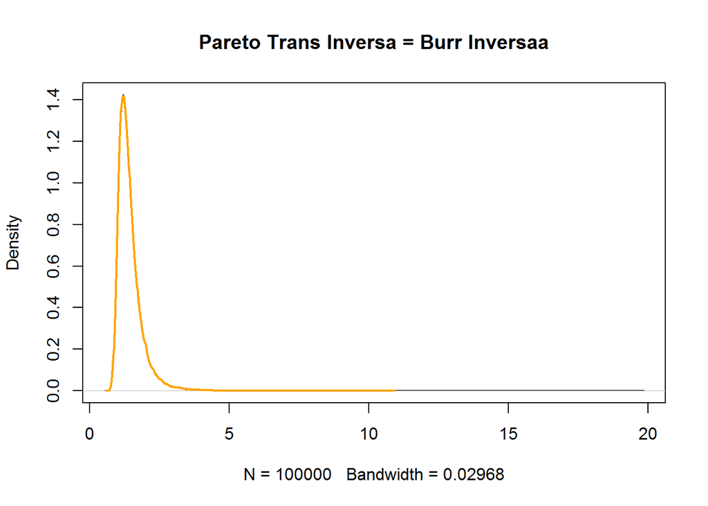

```r
set.seed(553878)
alpha <- 9
beta <- 3
theta <- 3 #son las mismas


tau <- -5
paretos <- rpareto(100000, alpha, beta)
y <- paretos^(1/tau)

burrsinversas<-rinvburr(100000, alpha, -tau, theta^(-1/tau))

plot(density(burrsinversas), main = "Pareto Trans Inversa = Burr Inversaa")
lines(density(y), type = "l", col="orange", lwd=2)
```

SUERTE!!